# Generate PRS for S3

Author

Arvid Harder

# Visualizing PRS metrics

I generated PRS using SbayesR using PGC_wave3_exclSweden as discovery sumstats. Individuals in several cohorts were deduplicated, and I’ve restricted to individuals of european ancestry usings principal components from Robert.

Ricopili returns several different sets of qc:ed variants. I use the BG genotype format (The format with the least strict qc filters).

## How many individuals are in S3?

I found a total of 11,717 individuals with genetic data AND PCs of which 11,007 are of european ancestry.

```r
tot_row <- select(res[[1]],cohort,N, ncas, ncon) %>% summarise(across(2:4,sum))

res[[1]] %>%
  mutate(pct_case = round(ncas/N, 2)) %>%
  select(cohort, pct_case, N, ncas, ncon)
```

```
   cohort pct_case     N ncas ncon
1: pf1176     0.45  1142  519  623
2: rl2041     0.47   712  335  377
3: si2297     0.22  5546 1208 4338
4: ssipku     0.63  3607 2268 1339
5: merged     0.39 11007 4330 6677
```

## How many SNPs are used for PRS?

The different S3 cohorts all varied in their overlap with Hapmap3 SNPs, which are the SNPs that SbayesR uses. As a first analysis i used all SNPs that were available for each cohort - resulting in some differences in the amount of SNPs used for each cohort. As i will show later, there is some differences in PRS association between the cohorts.

To remove other sources of variation, i’ve also plotted a PRS base only on the 583k snps that are present in all four cohorts.

Secondly, whether to standardise the PRS in each cohort, or in the full cohort is an open question.

All results presented below are from a logistic regression of SCZ case status on SCZ PRS and PC 1-5.

# Why is the number of SNPs used in PRS low?

See the following table for how this works out numerically. Row one displays the total number of SNPs in the discovery sumtats, and total snps after matching with the hapmap3 set.

Second row displays number of SNPs after applying filters, and then matching with hapmap3.

Third row displays number of SNPs after applying filters, matching with SNPs in PKU and then matching with hapmap3.

Fourth row shows the match between PKU and discovery sumsats, without any filters.

```r
tribble(
  ~qc, ~total_snps, ~snps_matching_hm3,
  "None",         7585076,           1144946,
  "INFO_MAF",     4035756,            870173,
  "overlap_with_PKU",    3017103,            633699,
  "PKU_overlap_without_filters", 7585076,         844950,
)
```

```
# A tibble: 4 × 3
  qc                          total_snps snps_matching_hm3
  <chr>                            <dbl>             <dbl>
1 None                           7585076           1144946
2 INFO_MAF                       4035756            870173
3 overlap_with_PKU               3017103            633699
4 PKU_overlap_without_filters    7585076            844950
```

The number of SNPs matching the the SbayesR rescaled hm3 set varies between cohorts. There is a small difference between the following figure and the one above, due to some small filters that SbayesR applies (ambigious variants for example)

```r
n_snps %>%
  arrange(desc(n_snps)) %>%
  add_row(name = "merged", n_snps = 583000) %>%
  knitr::kable()
```

| name | n_snps |
| --- | --- |
| pf1176 | 671047 |
| si2297 | 655912 |
| rl2041 | 635905 |
| ssipku | 616843 |
| merged | 583000 |

## Plotting Odds ratio in each cohort

For the analysis of the merged cohort i standardize the PRS within the full sample. Results from the individual cohorts are from a PRS standardized within each cohort.

Here we can see that PRS performs significantly worse in the ssipku sample.

Using the smaller set of common SNPs primarily affects the odds-ratio in the merged cohort, and does not affect the underperformance of the PRS in the pku samples.

noSwe_838k: 838k snps from the scz_pgc3 matched with the the 1.08 mil hapmap3 snps used by sbayesR. In each cohort, all snps available were used. PGC3 - the full PGC3 sumstats (including swe) - Kaarina mentioned the overlap with S3 might not be very large S3_583k_subset_after - 583k SNPs present in all S3 cohorts. Here i simply subset noSwe_838k to 583k snps present in all cohorts. S3_583k_subset_before - SbayesR “smears” effect sizes across LD loci. Here i subset the SNPs passed to SbayesR first, and then rescale the remaining 583k.

**side by side**

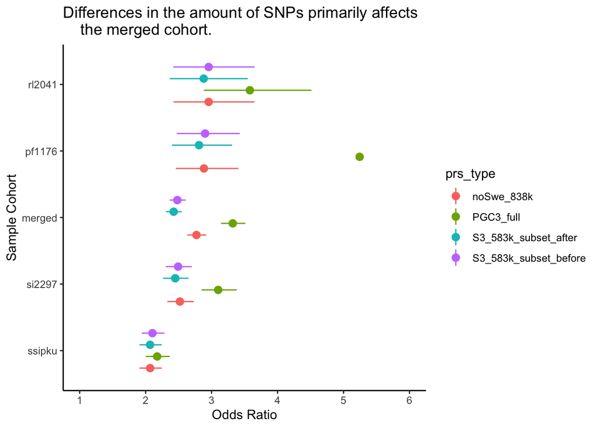

```r
df %>%
  mutate(cohort = fct_reorder(cohort, estimate)) %>%
  ggplot(aes(cohort, estimate, color = prs_type)) +
  geom_point(position = position_dodge(width = 0.7)) +
  geom_pointrange(aes(ymin = conf.low, ymax = conf.high),
                  position = position_dodge(width = 0.7)) +
  coord_flip() +
  labs(
    y = "Odds Ratio",
    x = "Sample Cohort",
    title = "Differences in the amount of SNPs primarily affects
    the merged cohort."
  ) +
  scale_y_continuous(limits = c(1,6), breaks = seq(1, 6, by = 1))
```

**Using all SNPs available in each cohort**

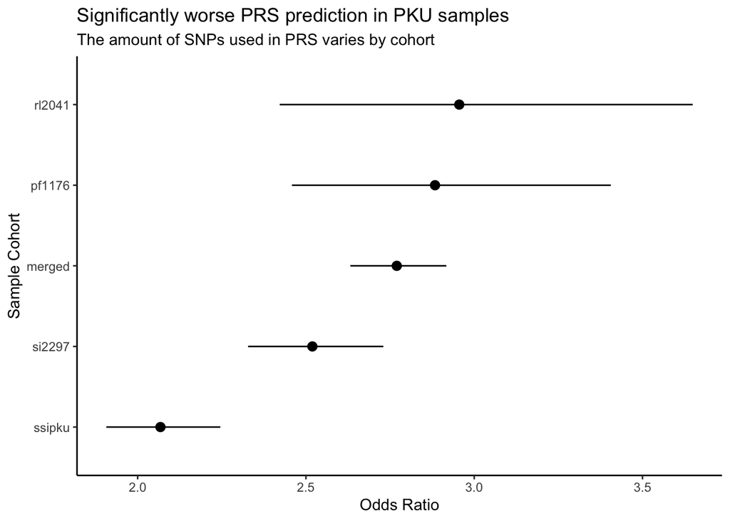

```r
df %>%

  filter(prs_type == "noSwe_838k") %>%
  mutate(cohort = fct_reorder(cohort, estimate)) %>%
  ggplot(aes(cohort, estimate)) +
  geom_point() +
  geom_pointrange(aes(ymin = conf.low, ymax = conf.high)) +
  coord_flip() +
  labs(
    y = "Odds Ratio",
    x = "Sample Cohort",
    title = "Significantly worse PRS prediction in PKU samples",
    subtitle = "The amount of SNPs used in PRS varies by cohort"
  )
```

**Using only SNPs present in all cohorts**

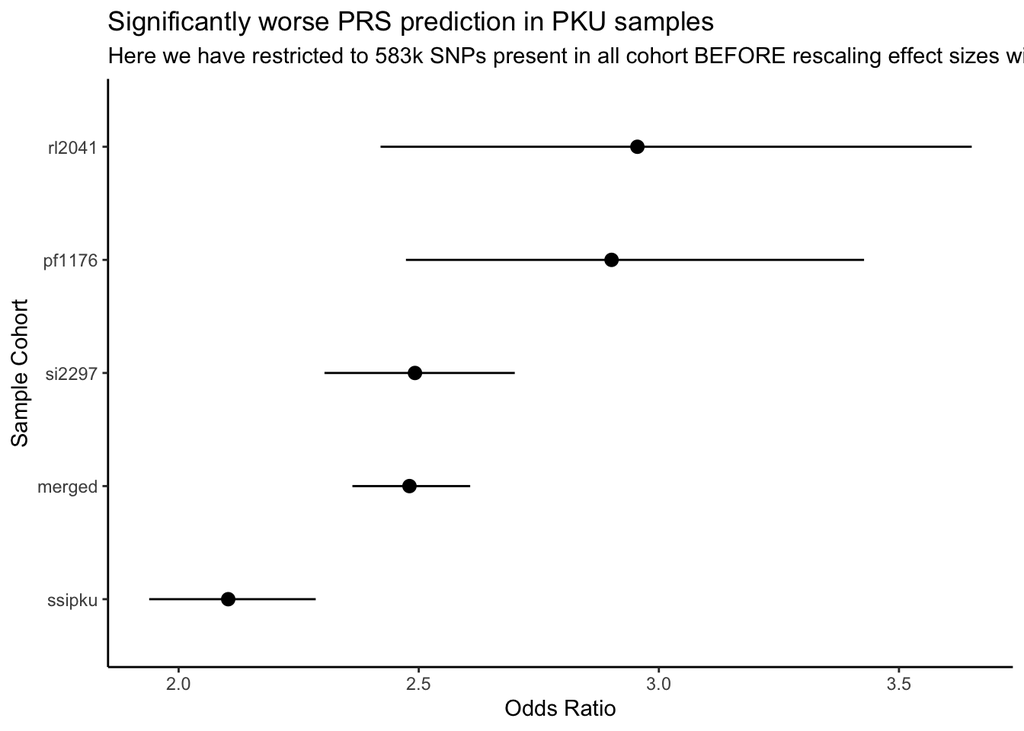

```r
df %>%
  filter(prs_type ==  "S3_583k_subset_before") %>%
  mutate(cohort = fct_reorder(cohort, estimate)) %>%
  ggplot(aes(cohort, estimate)) +
  geom_point() +
  geom_pointrange(aes(ymin = conf.low, ymax = conf.high)) +
  coord_flip() +
  labs(
    y = "Odds Ratio",
    x = "Sample Cohort",
    title = "Significantly worse PRS prediction in PKU samples",
    subtitle = "Here we have restricted to 583k SNPs present in all cohort BEFORE rescaling effect sizes with SbayesR"
  )
```

**R2 and auc**

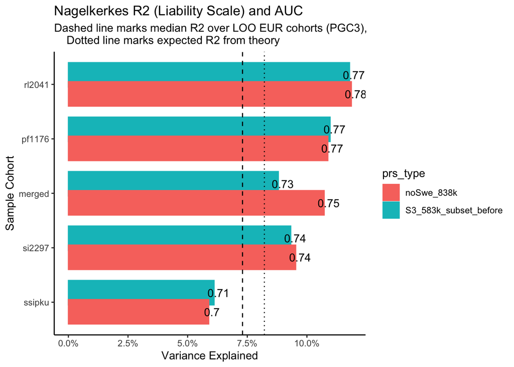

```r
pgc3_med <- 0.073

expected <- e_r2(0.24, m = 50000, n = neff(47248, 63612))

df %>%
  filter(prs_type %in% c("S3_583k_subset_before", "noSwe_838k")) %>%
  mutate(cohort = fct_reorder(cohort, nagel_lia)) %>%
  ggplot(aes(cohort, nagel_lia, fill = prs_type, label = round(auc, 2), color = prs_type)) +
  geom_col(position = position_dodge(width = 0.7)) +
  geom_text(hjust = 0.3, position = position_dodge(width = 0.7),
            color = "black") +
  geom_hline(yintercept = pgc3_med, linetype = "dashed") +
  geom_hline(yintercept = expected, linetype = "dotted") +
  coord_flip() +
  labs(
    y = "Variance Explained",
    x = "Sample Cohort",
    title = "Nagelkerkes R2 (Liability Scale) and AUC",
    subtitle = "Dashed line marks median R2 over LOO EUR cohorts (PGC3),
    Dotted line marks expected R2 from theory"
  ) +
  scale_y_continuous(labels = percent_format())
```

## Average PRS in cases and controls

Here i standardise the PRS in the merged cohort, and then compute the average PRS for cases and controls, stratified by cohort. While using all SNPs possible increased the association of case status with PRS, it introduces significant differences in terms of average PRS across cohorts for cases and controls. - THIS IS LIKELY DUE TO case/control differences in each cohort.

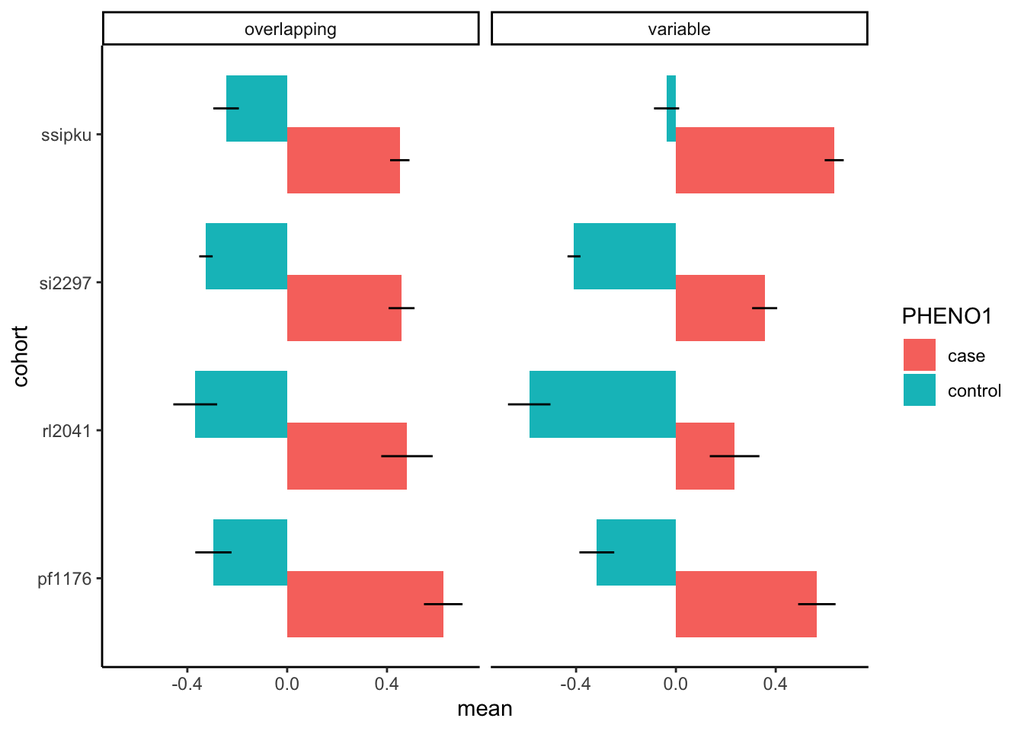

```r
avg_merge %>%
  mutate(PHENO1 = factor(PHENO1)) %>%
  ggplot(aes(cohort, mean, fill = PHENO1)) +
  geom_col(position = position_dodge(width = 0.7)) +
  geom_linerange(aes(ymin = mean - 1.96*se, ymax = mean + 1.96*se),
                 position = position_dodge(width = 0.7)) +
  coord_flip() +
  facet_wrap(~snps)
```

# Interpretation

That the PRS under-performs in the PKU sample is consistent across the ways i’ve perturbed the process of generating PRS.

I’m confused by the relationship between average PRS and odds-ratio/R2/AUC. For example, using the smaller set of SNPs does not impact odds-ratio within each cohort, but in the merged cohort we observe a significant difference. After discussing this with Robert, we believe that this part is odd.